# Kaggle BBC News Using NMF

```python
#Base packages
import pandas as pd
import numpy as np


#Text Modeling
from sklearn.feature_extraction.text import TfidfVectorizer, CountVectorizer
from sklearn.decomposition import NMF
from sklearn.feature_extraction import text

#Text Processing
import nltk
from nltk.corpus import stopwords
from nltk import word_tokenize, pos_tag
from nltk.stem import WordNetLemmatizer

#EDA and Visualization
from textblob import TextBlob
import seaborn as sns
import matplotlib.pyplot as plt

#String cleaning
import string

#Show images
from IPython.display import Image
```

```python
!pip install textblob
```

```python
train_df = pd.read_csv("data/BBC News Train.csv")
test_df = pd.read_csv("data/BBC News Test.csv")
```

```python
#Allows us to read more of the text
pd.set_option('max_colwidth', 150)
```

# Initial EDA of Response Variable

```python
train_df.head(10)
```

|  | ArticleId | Text | Category |
| --- | --- | --- | --- |
| 0 | 1833 | worldcom ex-boss launches defence lawyers defending former worldcom chief bernie ebbers against a battery of fraud charges have called a company w... | business |
| 1 | 154 | german business confidence slides german business confidence fell in february knocking hopes of a speedy recovery in europe s largest economy. mu... | business |
| 2 | 1101 | bbc poll indicates economic gloom citizens in a majority of nations surveyed in a bbc world service poll believe the world economy is worsening. ... | business |
| 3 | 1976 | lifestyle governs mobile choice faster better or funkier hardware alone is not going to help phone firms sell more handsets research suggests.... | tech |
| 4 | 917 | enron bosses in $168m payout eighteen former enron directors have agreed a $168m (£89m) settlement deal in a shareholder lawsuit over the collapse... | business |
| 5 | 1582 | howard truanted to play snooker conservative leader michael howard has admitted he used to play truant to spend time with his school friends at ... | politics |
| 6 | 651 | wales silent on grand slam talk rhys williams says wales are still not thinking of winning the grand slam despite a third six nations win. that ... | sport |
| 7 | 1797 | french honour for director parker british film director sir alan parker has been made an officer in the order of arts and letters one of france s... | entertainment |
| 8 | 2034 | car giant hit by mercedes slump a slump in profitability at luxury car maker mercedes has prompted a big drop in profits at parent daimlerchrysler... | business |
| 9 | 1866 | fockers fuel festive film chart comedy meet the fockers topped the festive box office in north america setting a new record for christmas day. t... | entertainment |

```python
train_df.info()
```

```
<class 'pandas.core.frame.DataFrame'>
RangeIndex: 1490 entries, 0 to 1489
Data columns (total 3 columns):
 #   Column     Non-Null Count  Dtype
---  ------     --------------  -----
 0   ArticleId  1490 non-null   int64
 1   Text       1490 non-null   object
 2   Category   1490 non-null   object
dtypes: int64(1), object(2)
memory usage: 35.0+ KB
```

```
The number of nulls for category type is:  0
```

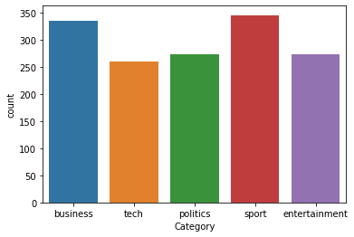

```python
print('The number of nulls for category type is: ', train_df['Category'].isnull().sum())
sns.countplot(x="Category", data=train_df)
```

# Cleaning and Tokenization Preparation

First, we want to set the index as the `ArticleId`. This will help documents stay associated with their topic when the dataframe is split.

```python
train_df = train_df.set_index('ArticleId')
```

### Normalizing Text

- Here are the steps taken to prepare the text for modeling. The process in preparing the data for moedling is called *normalizing*. Essentially, it prepares to standardize the text so different variations of a word (eat, ate, Eat, eaten) all are viewed the same
  - It seems it has already been converted to lowercase; however, we are looked at only a few documents. Thus, we need to ensure text in all documents are in lower case by converting them. This will prevent the model from viewing words like **Pizza** differently than **pizza**.
  - Next, urls in articles are typically contained with a 'www.'. URLs are not helpful in identifying common terms. Therefore, we will remove any of these urls from our text.
  - Third, we need to remove all punctuation and numbers as they can create noise for our model. Puncutation is meant for clarity. It does not provide semantic valuee.
  - Last we need to remove all digits from the model as the variation in numbers gives us very little information.

```python
train_df.iloc[0]['Text']
```

```
'worldcom ex-boss launches defence lawyers defending former worldcom chief bernie ebbers against a battery of fraud charges have called a company whistleblower as their first witness.  cynthia cooper  worldcom s ex-head of internal accounting  alerted directors to irregular accounting practices at t…
```

```python
train_df.iloc[1]['Text']
```

```
'german business confidence slides german business confidence fell in february knocking hopes of a speedy recovery in europe s largest economy.  munich-based research institute ifo said that its confidence index fell to 95.5 in february from 97.5 in january  its first decline in three months. the st…
```

```python
# convert text to lowercase
train_df['Text'] = train_df['Text'].str.lower()
test_df['Text'] = test_df['Text'].str.lower()

#remove any website reference
train_df['Text'] = train_df['Text'].str.replace(r"www\S+", "", regex=True)
test_df['Text'] = test_df['Text'].str.replace(r"www\S+", "", regex=True)

# remove all symbols and punctuation
trans = str.maketrans("", "", string.punctuation)
train_df['Text'] = train_df['Text'].str.translate(trans)
test_df['Text'] = test_df['Text'].str.translate(trans)

#remove all digts
trans = str.maketrans("", "", string.digits)
train_df['Text'] = train_df['Text'].str.translate(trans)
test_df['Text'] = test_df['Text'].str.translate(trans)
```

### Tokenazation

First, we need to create a method that tokenizes and lemmatizes our string. **Tokenzation** is the process of taking a string and separate the string into individual words. Separating each word into a list will help us analyze each word individually. After tokenizing the string, we can convert each word into it's base word. This will prevent instances when *eats* is counted differently than *eat*.

```python
nltk.download('stopwords')
lemmatizer = WordNetLemmatizer()
stopwords = set(stopwords.words('english'))

#Add own words to remove from text
custom_words = ['said', 'say', 'ha', 'wa', 'bn', "would", "also", "could"]
stopwords.update(custom_words)


def preprocess(article):
    """
    Method to tokenize and lemmatize string
    """
    new_words = []
    #create a list of all the words in the string
    words = word_tokenize(article)

    #remove stopwords
    for word in words:
        if word not in stopwords:
            new_words.append(word)

    #convert words to base format
    lemmatized = ' '.join([lemmatizer.lemmatize(word) for word in new_words])
    return lemmatized
```

```python
train_df['Text'] =train_df['Text'].apply(preprocess)
test_df['Text'] =test_df['Text'].apply(preprocess)
train_df
```

| ArticleId | Text | Category |
| --- | --- | --- |
| 1833 | worldcom exboss launch defence lawyer defending former worldcom chief bernie ebbers battery fraud charge called company whistleblower first witnes... | business |
| 154 | german business confidence slide german business confidence fell february knocking hope speedy recovery europe largest economy munichbased researc... | business |
| 1101 | bbc poll indicates economic gloom citizen majority nation surveyed bbc world service poll believe world economy worsening respondent national econ... | business |
| 1976 | lifestyle governs mobile choice faster better funkier hardware alone going help phone firm sell handset research suggests instead phone firm keen ... | tech |
| 917 | enron boss payout eighteen former enron director agreed £m settlement deal shareholder lawsuit collapse energy firm leading plaintiff university c... | business |
| ... | ... | ... |
| 857 | double eviction big brother model caprice holby city actor jeremy edward left celebrity big brother house surprise double eviction friday caprice ... | entertainment |
| 325 | dj double act revamp chart show dj duo jk joel taking bbc radio flagship chart show sunday adding showbiz news celebrity interview betweensong ban... | entertainment |
| 1590 | weak dollar hit reuters revenue medium group reuters slipped mainly due weakness dollar group company optimistic growth even revenue slipped £bn £... | business |
| 1587 | apple ipod family expands market apple expanded ipod family release next generation digital music player latest challenge growing digital music ga... | tech |
| 538 | santy worm make unwelcome visit thousand website bulletin board defaced virus used google spread across net santy worm first appeared december wit... | tech |

1490 rows × 2 columns

# EDA

Now that we have prepared our text, lets take our analysis a bit further and review the following:

- **Polarity per category**
  - Do different categories have a more positice outlook than others?
- **Subjectivity per category**
  - Are different categories more opinion based?
- **Word count per category**
  - Are articles from different categories longer?
- **Top words per category**

```python
# add polarity scores
train_df['polarity'] = train_df['Text'].map(lambda text: TextBlob(text).sentiment.polarity)

#add subjectivity scores
train_df['subjectivity'] = train_df['Text'].map(lambda text: TextBlob(text).sentiment.subjectivity)

#add review word count
train_df['word_count'] = train_df['Text'].apply(lambda text: len(text.split()))
```

### Polarity

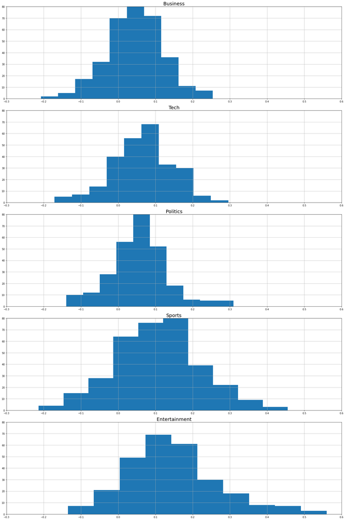

```python
#Polarity grid
fig, ax = plt.subplots(5,1, figsize=(20, 30))

train_df.loc[train_df['Category'] == 'business', 'polarity'].hist(ax = ax[0])
ax[0].set_title('Business', fontsize=20)
ax[0].set_xlim(-0.3, 0.6)
ax[0].set_ylim(0, 80)

train_df.loc[train_df['Category'] == 'tech', 'polarity'].hist(ax = ax[1])
ax[1].set_title('Tech', fontsize=20)
ax[1].set_xlim(-0.3, 0.6)
ax[1].set_ylim(0, 80)


train_df.loc[train_df['Category'] == 'politics', 'polarity'].hist(ax = ax[2])
ax[2].set_title('Politics', fontsize=20)
ax[2].set_xlim(-0.3, 0.6)
ax[2].set_ylim(0, 80)

train_df.loc[train_df['Category'] == 'sport', 'polarity'].hist(ax = ax[3])
ax[3].set_title('Sports', fontsize=20)
ax[3].set_xlim(-0.3, 0.6)
ax[3].set_ylim(0, 80)

train_df.loc[train_df['Category'] == 'entertainment', 'polarity'].hist(ax = ax[4])
ax[4].set_title('Entertainment', fontsize=20)
ax[4].set_xlim(-0.3, 0.6)
ax[4].set_ylim(0, 80)

fig.tight_layout()
```

### Subjectivity

Subjectivity measures how opinionated a text is. With a range between 0 and 1, a text has a score closer to 1 if it is more opinion based. Subjectivity looks for the occurrence of adverbs. For example, *She walked away angrily* would have a higher subjectivity score than *She walked away*. For our data, all 5 categories have a median subjectivity score around 0.4. Thus, all of our articles are slightly opinion-based.

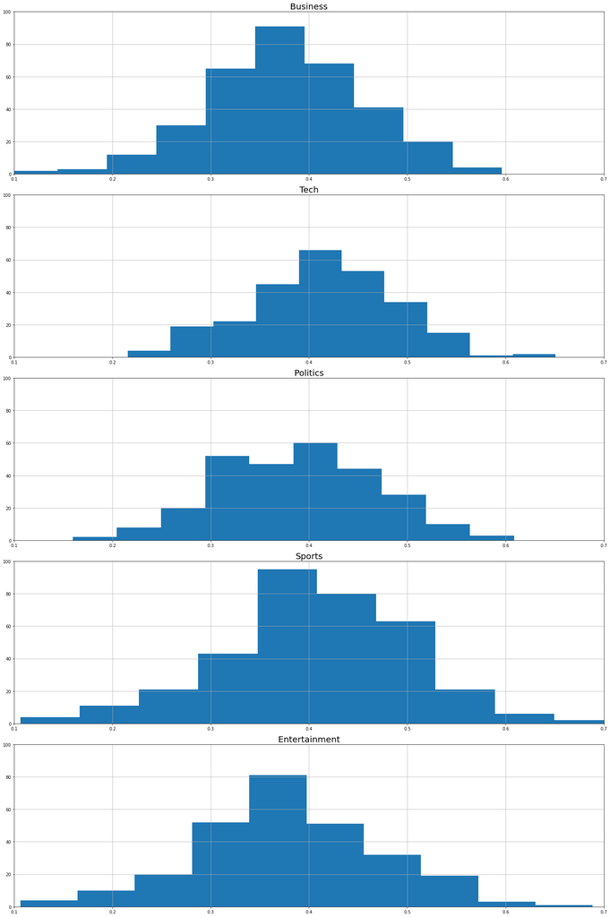

```python
#Subjectivity
fig, ax = plt.subplots(5,1, figsize=(20, 30))

train_df.loc[train_df['Category'] == 'business', 'subjectivity'].hist(ax = ax[0])
ax[0].set_title('Business', fontsize=20)
ax[0].set_xlim(0.1, 0.7)
ax[0].set_ylim(0, 100)

train_df.loc[train_df['Category'] == 'tech', 'subjectivity'].hist(ax = ax[1])
ax[1].set_title('Tech', fontsize=20)
ax[1].set_xlim(0.1, 0.7)
ax[1].set_ylim(0, 100)


train_df.loc[train_df['Category'] == 'politics', 'subjectivity'].hist(ax = ax[2])
ax[2].set_title('Politics', fontsize=20)
ax[2].set_xlim(0.1, 0.7)
ax[2].set_ylim(0, 100)

train_df.loc[train_df['Category'] == 'sport', 'subjectivity'].hist(ax = ax[3])
ax[3].set_title('Sports', fontsize=20)
ax[3].set_xlim(0.1, 0.7)
ax[3].set_ylim(0, 100)

train_df.loc[train_df['Category'] == 'entertainment', 'subjectivity'].hist(ax = ax[4])
ax[4].set_title('Entertainment', fontsize=20)
ax[4].set_xlim(0.1, 0.7)
ax[4].set_ylim(0, 100)

fig.tight_layout()
```

### Word Count

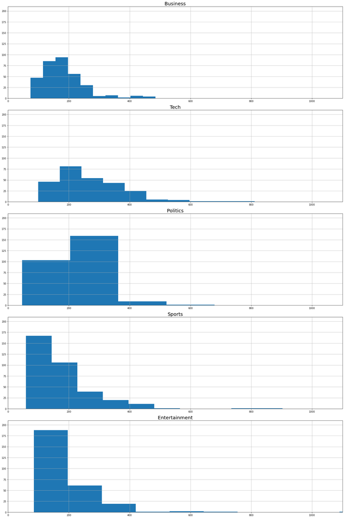

```python
#Word Length
fig, ax = plt.subplots(5,1, figsize=(20, 30))

train_df.loc[train_df['Category'] == 'business', 'word_count'].hist(ax = ax[0])
ax[0].set_title('Business', fontsize=20)
# ax[0].set_xlim(0.1, 0.7)
ax[0].set_ylim(0, 210)
ax[0].set_xlim(0, 1100)

train_df.loc[train_df['Category'] == 'tech', 'word_count'].hist(ax = ax[1])
ax[1].set_title('Tech', fontsize=20)
ax[1].set_xlim(0, 1100)
ax[1].set_ylim(0, 210)


train_df.loc[train_df['Category'] == 'politics', 'word_count'].hist(ax = ax[2])
ax[2].set_title('Politics', fontsize=20)
ax[2].set_xlim(0, 1100)
ax[2].set_ylim(0, 210)

train_df.loc[train_df['Category'] == 'sport', 'word_count'].hist(ax = ax[3])
ax[3].set_title('Sports', fontsize=20)
ax[3].set_xlim(0, 1100)
ax[3].set_ylim(0, 210)

train_df.loc[train_df['Category'] == 'entertainment', 'word_count'].hist(ax = ax[4])
ax[4].set_title('Entertainment', fontsize=20)
ax[4].set_xlim(0, 1100)
ax[4].set_ylim(0, 210)

fig.tight_layout()

#Tech outliers of 1200, 1400
#Politics outliers of 2500, 3000
#Sports outliers of 1400, 1600
#entertainment 1500, 2500 outliers
```

```python
#Columns no longer needed
train_df.drop(['polarity', 'subjectivity', 'word_count'], axis=1, inplace=True)
```

### Converting to TF-IDF

Next, we need to convert our dataframe into a a model matrix format using **TF-IDF**. **TF-IDF** is short for "term frequency - inverse document frequency". Essentially, it is a statistic which evaluates how orignal a word is in a document compared to other documents in the collection. It is calculated by the following:

$$w_{i,j} = tf_{i,j} * log(\frac{N}{df_{i}})$$

- The terms stand for the following:
  - $tf_{i,j}$
    - the number of occurenced of term i in document j
  - $log(\frac{N}{df_{i}})$
    - the log of the total of the number of documents in the collection divided by the number of doucuments where term $i$ occurs

The higher the TF-IDF score the more rare the document is among the collection. In other words, it helps use identify the originality of the word. Thus, articles that have similar TF-IDF calculations should belong to the same category. We will use this matrix for our final EDA plot and our model.

```python
vectorizer = TfidfVectorizer(min_df=0.01)
X = vectorizer.fit_transform(train_df['Text'])
X_names = vectorizer.get_feature_names_out()
X_counts = X.toarray()
words_train_df = pd.DataFrame(X_counts, columns=X_names)
words_train_df.index = train_df.index
words_train_df['Category'] = train_df['Category']

#TFID to the test set set
X_test = vectorizer.transform(test_df['Text'])
```

### Important Words by Category

Next, measure each word's TF_IDF score by category. The top 10 original words for each category are listed. For example, `business` tends to be highly associated with words such as *firm*, company *and* market*. Again, these terms are expected as they are all usually associated with busines practices.* Game *is highly associated with `tech` and `sports`. Again, this is understandable as* game *could be associated with* video game *in the tech context; however,* game *refers to any rugby, soccer, basketball, etc. match. However, the term* game* is more often used with `sports` articles compared to `tech`; thus, its TF-IDF score is slightly higher in the `game` category.

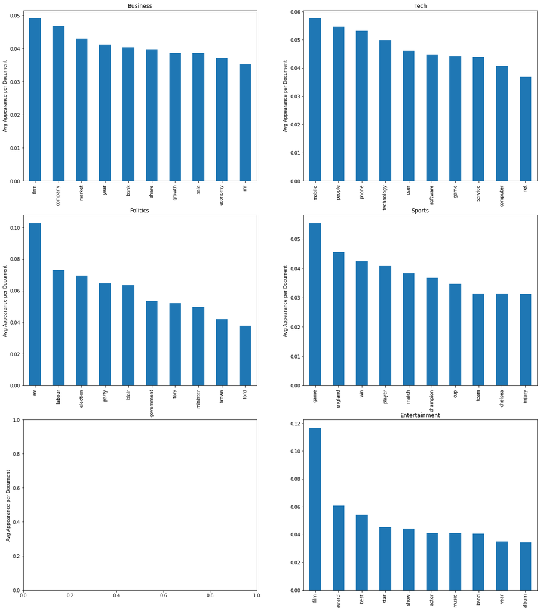

```python
fig, ax = plt.subplots(3,2, figsize=(20,20))

#Create average each word appearance by category
cat_group = words_train_df.groupby('Category').mean().transpose()

#Make subplots
cat_group['business'].sort_values(ascending=False).head(10).plot.bar(ax=ax[0,0])
ax[0,0].set_title('Business')
ax[0,0].set_ylabel("Avg Appearance per Document")

cat_group['tech'].sort_values(ascending=False).head(10).plot.bar(ax=ax[0,1])
ax[0,1].set_title('Tech')
ax[0,1].set_ylabel("Avg Appearance per Document")

cat_group['politics'].sort_values(ascending=False).head(10).plot.bar(ax=ax[1,0])
ax[1,0].set_title('Politics')
ax[1,0].set_ylabel("Avg Appearance per Document")

cat_group['sport'].sort_values(ascending=False).head(10).plot.bar(ax=ax[1,1])
ax[1,1].set_title('Sports')
ax[1,1].set_ylabel("Avg Appearance per Document")

cat_group['entertainment'].sort_values(ascending=False).head(10).plot.bar(ax=ax[2,1])
ax[2,1].set_title('Entertainment')
ax[2,0].set_ylabel("Avg Appearance per Document")
plt.subplots_adjust(top=1)
```

```python
words_train_df
```

| ArticleId | ability | able | abroad | absence | absolute | absolutely | abuse | academy | accept | accepted | ... | yen | yes | yet | york | young | younger | youngster | yukos | zealand | Category |
| --- | --- | --- | --- | --- | --- | --- | --- | --- | --- | --- | --- | --- | --- | --- | --- | --- | --- | --- | --- | --- | --- |
| 1833 | 0.0 | 0.000000 | 0.0 | 0.0 | 0.0 | 0.0 | 0.0 | 0.0 | 0.0 | 0.0 | ... | 0.0 | 0.0 | 0.000000 | 0.06083 | 0.000000 | 0.000000 | 0.000000 | 0.0 | 0.0 | business |
| 154 | 0.0 | 0.000000 | 0.0 | 0.0 | 0.0 | 0.0 | 0.0 | 0.0 | 0.0 | 0.0 | ... | 0.0 | 0.0 | 0.000000 | 0.00000 | 0.000000 | 0.000000 | 0.000000 | 0.0 | 0.0 | business |
| 1101 | 0.0 | 0.000000 | 0.0 | 0.0 | 0.0 | 0.0 | 0.0 | 0.0 | 0.0 | 0.0 | ... | 0.0 | 0.0 | 0.000000 | 0.00000 | 0.000000 | 0.000000 | 0.000000 | 0.0 | 0.0 | business |
| 1976 | 0.0 | 0.026793 | 0.0 | 0.0 | 0.0 | 0.0 | 0.0 | 0.0 | 0.0 | 0.0 | ... | 0.0 | 0.0 | 0.000000 | 0.00000 | 0.000000 | 0.086075 | 0.047011 | 0.0 | 0.0 | tech |
| 917 | 0.0 | 0.000000 | 0.0 | 0.0 | 0.0 | 0.0 | 0.0 | 0.0 | 0.0 | 0.0 | ... | 0.0 | 0.0 | 0.000000 | 0.00000 | 0.000000 | 0.000000 | 0.000000 | 0.0 | 0.0 | business |
| ... | ... | ... | ... | ... | ... | ... | ... | ... | ... | ... | ... | ... | ... | ... | ... | ... | ... | ... | ... | ... | ... |
| 857 | 0.0 | 0.000000 | 0.0 | 0.0 | 0.0 | 0.0 | 0.0 | 0.0 | 0.0 | 0.0 | ... | 0.0 | 0.0 | 0.000000 | 0.00000 | 0.000000 | 0.000000 | 0.000000 | 0.0 | 0.0 | entertainment |
| 325 | 0.0 | 0.000000 | 0.0 | 0.0 | 0.0 | 0.0 | 0.0 | 0.0 | 0.0 | 0.0 | ... | 0.0 | 0.0 | 0.000000 | 0.00000 | 0.000000 | 0.000000 | 0.000000 | 0.0 | 0.0 | entertainment |
| 1590 | 0.0 | 0.000000 | 0.0 | 0.0 | 0.0 | 0.0 | 0.0 | 0.0 | 0.0 | 0.0 | ... | 0.0 | 0.0 | 0.000000 | 0.00000 | 0.000000 | 0.000000 | 0.000000 | 0.0 | 0.0 | business |
| 1587 | 0.0 | 0.000000 | 0.0 | 0.0 | 0.0 | 0.0 | 0.0 | 0.0 | 0.0 | 0.0 | ... | 0.0 | 0.0 | 0.031244 | 0.00000 | 0.035156 | 0.000000 | 0.000000 | 0.0 | 0.0 | tech |
| 538 | 0.0 | 0.000000 | 0.0 | 0.0 | 0.0 | 0.0 | 0.0 | 0.0 | 0.0 | 0.0 | ... | 0.0 | 0.0 | 0.000000 | 0.00000 | 0.000000 | 0.000000 | 0.000000 | 0.0 | 0.0 | tech |

1490 rows × 2723 columns

# Matrix Factorization and Prediction

To model our text data, we will use **Non-negative Matrix Factorization**. This model is most appropriate for text data as it words best with non negative values. Essentially, we choose the number of components we want. This is typically the # of subtopics we care to find. In our case, we have five article topics; therefore, our number of components is defined as 5. NMF essentially takes our matrix of words of words an finds which group of words are highly associated with each other. Since we have 5 components, we are trying to find 5 different subgroups where the words of each subgroups are highly associated with eac other. In our context, 'associated with each other' is just saying they typically appear in the same articles. It does this by dividing the one matrix into two matrices. Thes first matrix (*W*) holds all the documents and the strength of their relationship with each of the 5 components. The second component, (*X*), contains each component and their relationship strength with each term from our orginal matrix. Multiplies togther, we get our original term matrix. In this assignment this matrix is called the **component matrix**. Once given our 5 components, we can find the words highly associated with the 5 components.

```python
# Create our NMF model with TFID matrix
nmf_model = NMF(n_components=5, random_state=50234)
nmf_model.fit(X)

#Get the 'W' matrix or otherwise known as feature matrix
features_W_train= nmf_model.transform(X)

features_W_test = nmf_model.transform(X_test)
features_W_train
```

```
array([[0.0006312 , 0.05736616, 0.0068038 , 0.00612928, 0.06571773],
       [0.        , 0.        , 0.        , 0.        , 0.21133278],
       [0.01326897, 0.03355332, 0.02112035, 0.00442349, 0.11377787],
       ...,
       [0.00320843, 0.        , 0.        , 0.00529825, 0.15636686],
       [0.        , 0.        , 0.19952899, 0.00575212, 0.02248878],
       [0.        , 0.        , 0.13301219, 0.        , 0.        ]])
```

```python
# Get the Component Matrix
components_X = pd.DataFrame(nmf_model.components_, columns=vectorizer.get_feature_names_out())
components_X.index.name = 'components'
components_X
```

| components | ability | able | abroad | absence | absolute | absolutely | abuse | academy | accept | accepted | ... | yearold | yen | yes | yet | york | young | younger | youngster | yukos | zealand |
| --- | --- | --- | --- | --- | --- | --- | --- | --- | --- | --- | --- | --- | --- | --- | --- | --- | --- | --- | --- | --- | --- |
| 0 | 0.013500 | 0.042881 | 0.005232 | 0.035521 | 0.009952 | 0.029570 | 0.002454 | 0.000000 | 0.008425 | 0.012057 | ... | 0.185388 | 0.000000 | 0.006685 | 0.046776 | 0.017894 | 0.059762 | 0.013806 | 0.031986 | 0.000000 | 0.098389 |
| 1 | 0.022399 | 0.028321 | 0.011509 | 0.000000 | 0.006227 | 0.018972 | 0.011471 | 0.000000 | 0.015009 | 0.015730 | ... | 0.008952 | 0.000000 | 0.013312 | 0.023662 | 0.004697 | 0.030768 | 0.012741 | 0.000241 | 0.002202 | 0.000000 |
| 2 | 0.032060 | 0.083283 | 0.001376 | 0.000000 | 0.000566 | 0.000000 | 0.009991 | 0.000000 | 0.006377 | 0.001333 | ... | 0.000000 | 0.000000 | 0.006517 | 0.037528 | 0.023684 | 0.016585 | 0.010980 | 0.003017 | 0.000000 | 0.000000 |
| 3 | 0.000489 | 0.009597 | 0.000000 | 0.003987 | 0.005176 | 0.006144 | 0.000522 | 0.130818 | 0.004549 | 0.002711 | ... | 0.037909 | 0.005315 | 0.000000 | 0.029095 | 0.037381 | 0.040624 | 0.002768 | 0.000000 | 0.000000 | 0.000000 |
| 4 | 0.002906 | 0.011287 | 0.014975 | 0.000000 | 0.002058 | 0.004525 | 0.001885 | 0.000000 | 0.013453 | 0.014057 | ... | 0.002963 | 0.053278 | 0.000000 | 0.021894 | 0.045634 | 0.000527 | 0.000000 | 0.000000 | 0.144942 | 0.000000 |

5 rows × 2722 columns

Now that we have our components, we can view how each of the words are associated with them. We can see the 5 plots are very similar to our word plots we calculated earlier. In fact, we can see the following components are associated with the following categories:

- **Component 0** : `Sports`
- **Component 1** : `Politics`
- **Component 2** : `Tech`
- **Component 3** : `Entertainment`
- **Component 4** : `Business`

Now, we can appropriately map each component to the appropriate category.

- https://www.kaggle.com/code/tranquilmorning/nmf-tutorials/notebook

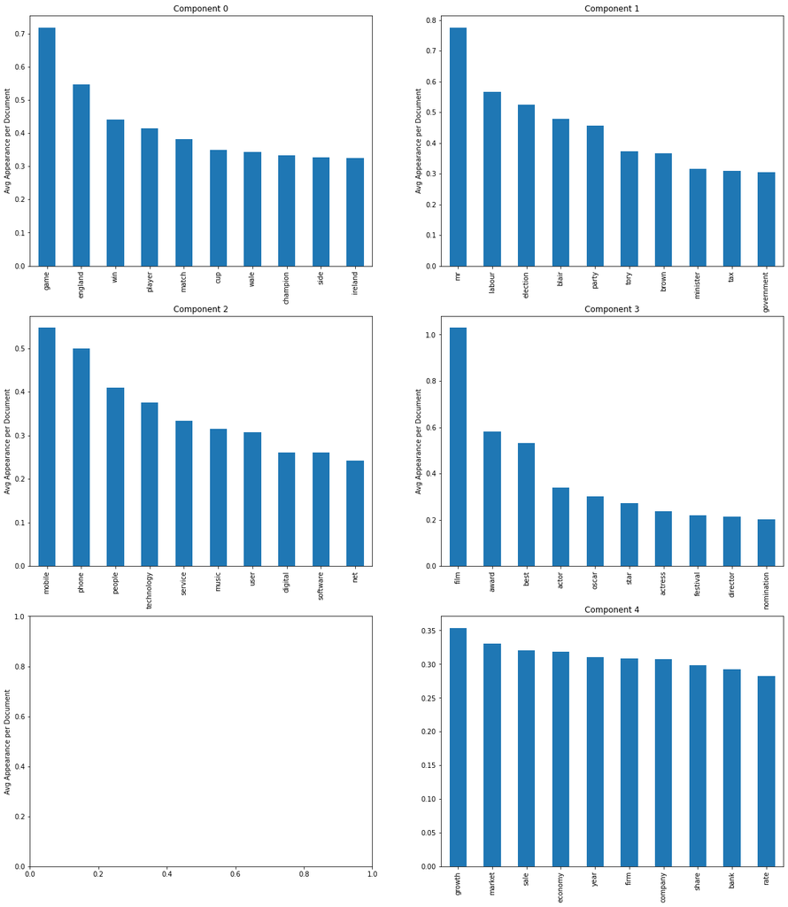

```python
components_group = components_X.groupby('components').mean().transpose()

fig, ax = plt.subplots(3,2, figsize=(20,20))

components_group[0].sort_values(ascending=False).head(10).plot.bar(ax=ax[0,0])
ax[0,0].set_title('Component 0')
ax[0,0].set_ylabel("Avg Appearance per Document")

components_group[1].sort_values(ascending=False).head(10).plot.bar(ax=ax[0,1])
ax[0,1].set_title('Component 1')
ax[0,1].set_ylabel("Avg Appearance per Document")

components_group[2].sort_values(ascending=False).head(10).plot.bar(ax=ax[1,0])
ax[1,0].set_title('Component 2')
ax[1,0].set_ylabel("Avg Appearance per Document")

components_group[3].sort_values(ascending=False).head(10).plot.bar(ax=ax[1,1])
ax[1,1].set_title('Component 3')
ax[1,1].set_ylabel("Avg Appearance per Document")

components_group[4].sort_values(ascending=False).head(10).plot.bar(ax=ax[2,1])
ax[2,1].set_title('Component 4')
ax[2,0].set_ylabel("Avg Appearance per Document")
plt.subplots_adjust(top=1)
```

```python
#Get dataframe with category associated with component
class_matrix = pd.DataFrame({'component': [0,1,2,3,4], 'category': ['sport', 'politics', 'tech', 'entertainment', 'business']})

#Create prediction matrix.
# For each article, chooses component with highest score
pred_matrix_train = pd.DataFrame({'component': pd.DataFrame(features_W_train).idxmax(axis=1)})


#Maps component to appropriate category name
train_preds = pred_matrix_train.merge(class_matrix, how='left', on='component')
train_preds
```

|  | component | category |
| --- | --- | --- |
| 0 | 4 | business |
| 1 | 4 | business |
| 2 | 4 | business |
| 3 | 2 | tech |
| 4 | 4 | business |
| ... | ... | ... |
| 1485 | 3 | entertainment |
| 1486 | 2 | tech |
| 1487 | 4 | business |
| 1488 | 2 | tech |
| 1489 | 2 | tech |

1490 rows × 2 columns

```python
pred_matrix_test = pd.DataFrame({'component': pd.DataFrame(features_W_test).idxmax(axis=1)})
test_preds = pred_matrix_test.merge(class_matrix, how='left', on='component')
test_preds
```

|  | component | category |
| --- | --- | --- |
| 0 | 0 | sport |
| 1 | 2 | tech |
| 2 | 0 | sport |
| 3 | 4 | business |
| 4 | 0 | sport |
| ... | ... | ... |
| 730 | 4 | business |
| 731 | 3 | entertainment |
| 732 | 2 | tech |
| 733 | 4 | business |
| 734 | 1 | politics |

735 rows × 2 columns

## Model Evaluation

As we can see below, our model did quite well. Overall, it is 92% accurate. Our classes were balanced, thus, accuracy is a good metric in this case. Also, our model has very high recall and precision scores. Precision measures the percentage of times our document is the cateogry we predict it as. Recall measures the percentage of a class we correctly classified as that class. Last, our accuracy score is the same for the test set and the training set; thus, we didn't train our model in a way that overfit the data.

```python
from sklearn.metrics import roc_auc_score, classification_report, confusion_matrix, accuracy_score

print(classification_report(train_df['Category'], train_preds['category']))
confusion_matrix(train_df['Category'], train_preds['category'])
```

```
               precision    recall  f1-score   support

     business       0.90      0.93      0.91       336
entertainment       0.95      0.82      0.88       273
     politics       0.91      0.91      0.91       274
        sport       0.97      0.98      0.97       346
         tech       0.86      0.92      0.89       261

     accuracy                           0.92      1490
    macro avg       0.92      0.91      0.91      1490
 weighted avg       0.92      0.92      0.92      1490
```

```
array([[313,   1,  14,   0,   8],
       [ 11, 224,   8,   4,  26],
       [ 18,   0, 249,   3,   4],
       [  2,   3,   1, 340,   0],
       [  5,   7,   3,   5, 241]])
```

## Test Data

We cannot gather measurement regarding other metrics with teh test data. However, our model did score a 92% accuracy.

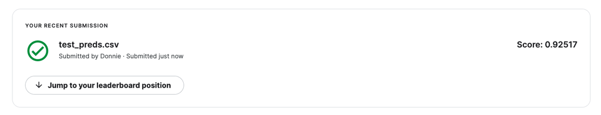

```python
Image(filename='first_submission_pic.png')
```

```python
test_df['category'] = test_preds['category']
test_df
```

|  | ArticleId | Text | category |
| --- | --- | --- | --- |
| 0 | 1018 | qpr keeper day head preston queen park ranger keeper chris day set join preston month loan day displaced arrival simon royce second month loan cha... | sport |
| 1 | 1319 | software watching work software monitor every keystroke action performed pc used legally binding evidence wrongdoing unveiled worry cybercrime sab... | tech |
| 2 | 1138 | arcy injury add ireland woe gordon arcy ruled ireland team saturday six nation clash scotland murrayfield like skipper brian driscoll arcy failed ... | sport |
| 3 | 459 | india reliance family feud heat ongoing public spat two heir india biggest conglomerate reliance group spilled board meeting leading company withi... | business |
| 4 | 1020 | boro suffer morrison injury blow middlesbrough midfielder james morrison ruled eight week operation tuesday yearold played club last game surgery ... | sport |
| ... | ... | ... | ... |
| 730 | 1923 | eu probe alitalia state aid european commission officially launched indepth investigation whether italian airline alitalia receiving illegal state... | business |
| 731 | 373 | u play grammy award show irish rock band u play live grammy award presentation u next month organiser act play include soul singer alicia key coun... | entertainment |
| 732 | 1704 | sport betting rule spotlight group mp peer called tightening regulation controlling betting sport parliamentary group betting gaming held substant... | tech |
| 733 | 206 | alfa romeo get gm engine fiat stop making sixcylinder petrol engine sporty alfa romeo subsidiary union italian carmaker union claim fiat close fia... | business |
| 734 | 471 | citizenship event touted citizenship ceremony introduced people celebrating th birthday charles clarke idea tried part overhaul way government app... | politics |

735 rows × 3 columns

```python
# test_df.drop(['Text'], axis = 1).to_csv('test_preds.csv', index = False)
```

# Comparison to Supervised Learning

Next, we would like to compare our matrix facotrized model to the **Multinomail Naive Bayes** model. This model is based off of a well known theorem in statistice: **The Baye's Theorem**. This theorem calculates conditional probability with the following theorem:

$$P(A|B)= P(A) * P(B|A)P(B)$$

In this case, A is our article category and B is our word. This probability calculation is known as the *posterior probability*. Our algorithim looks at each word to determine how likely that word would appear in different cateogries. Once the probability is calculated for each word, the algorithm determines the probability a document belongs to each class.The class with the highest probability is what the document is labeled as.

Naive Bayes is a good model for our dataset the dependency assumption works well with our data. Naive Bayes fails when predictors are dependent on other predictors; we assume each term is independent of another. This consitutes the 'Naive' part of the algorithm name.

Overall, our model scored very high. Again, because our classes are fairly balanced, accuracy is good measure on how well our model is doing. Our training data has an accuracy of 98%. Our test model was 96% accurate as shown by the picture below.

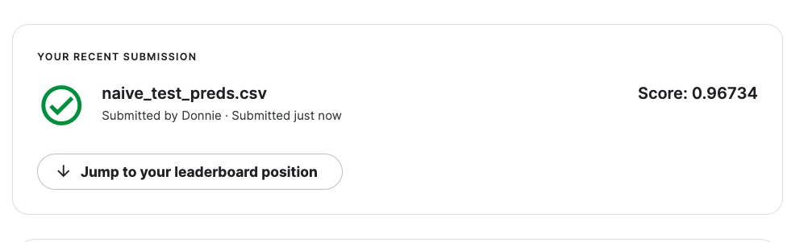

```python
Image(filename='naive_submission.png')
```

```python
from sklearn import model_selection, naive_bayes, svm
```

```python
#Fit Naive-Bayes Model
naive_mdl = naive_bayes.MultinomialNB()
naive_mdl.fit(words_train_df.drop('Category', axis=1), train_df['Category'])
preds_naive_train = naive_mdl.predict(words_train_df.drop('Category', axis=1))


print(classification_report(train_df['Category'], preds_naive_train))
confusion_matrix(train_df['Category'], preds_naive_train)
```

```
               precision    recall  f1-score   support

     business       0.98      0.99      0.98       336
entertainment       0.99      0.99      0.99       273
     politics       0.97      0.98      0.98       274
        sport       0.99      1.00      1.00       346
         tech       0.98      0.97      0.97       261

     accuracy                           0.98      1490
    macro avg       0.98      0.98      0.98      1490
 weighted avg       0.98      0.98      0.98      1490
```

```
array([[331,   0,   2,   0,   3],
       [  1, 270,   2,   0,   0],
       [  3,   0, 268,   1,   2],
       [  1,   0,   0, 345,   0],
       [  1,   3,   3,   1, 253]])
```

```python
#fit test set and get predictions
X_test_counts = X_test.toarray()
words_test_df = pd.DataFrame(X_test_counts, columns=X_names)
naive_preds = naive_mdl.predict(words_test_df)


naive_test_df = pd.DataFrame({'ArticleId': test_df['ArticleId'], 'category' : naive_preds})
```

```python
# naive_test_df.to_csv('naive_test_preds.csv', index = False)
```

# References

- Text Preprocessing

## - https://monkeylearn.com/blog/text-cleaning/

- EDA
  - https://textblob.readthedocs.io/en/dev/quickstart.html
  - https://data-science-blog.com/en/blog/2018/11/04/sentiment-analysis-using-python/
  - https://towardsdatascience.com/a-complete-exploratory-data-analysis-and-visualization-for-text-data-29fb1b96fb6a